# First things first: What does the data look like?

```python
# Hint: What do these numbers represent?
print('data shape:', X.shape)
print('label shape:', Y.shape)
```

```
data shape: (70000, 784)
label shape: (70000,)
```

# So what does it look like to the computer?

```python
# First record in dataset
X[0]
```

```
array([0.        , 0.        , 0.        , 0.        , 0.        ,
       0.        , 0.        , 0.        , 0.        , 0.        ,
       0.        , 0.        , 0.        , 0.        , 0.        ,
       0.        , 0.        , 0.        , 0.        , 0.        ,
       0.        , 0.        , 0.        , 0.        , 0.        ,
       0.        , 0.        , 0.        , 0.        , 0.        ,
       0.        , 0.        , 0.        , 0.        , 0.        ,
       0.        , 0.        , 0.        , 0.        , 0.        ,
       0.        , 0.        , 0.        , 0.        , 0.        ,
       0.        , 0.        , 0.        , 0.        , 0.        ,
       0.        , 0.        , 0.        , 0.        , 0.        ,
       0.        , 0.        , 0.        , 0.        , 0.        ,
       0.        , 0.        , 0.        , 0.        , 0.        ,
       0.        , 0.        , 0.        , 0.        , 0.        ,
       0.        , 0.        , 0.        , 0.        , 0.        ,
       0.        , 0.        , 0.        , 0.        , 0.        ,
       0.        , 0.        , 0.        , 0.        , 0.        ,
       0.        , 0.        , 0.        , 0.        , 0.        ,
       0.        , 0.        , 0.        , 0.        , 0.        ,
       0.        , 0.        , 0.        , 0.        , 0.        ,
       0.        , 0.        , 0.        , 0.        , 0.        ,
       0.        , 0.        , 0.        , 0.        , 0.        ,
       0.        , 0.        , 0.        , 0.        , 0.        ,
       0.        , 0.        , 0.        , 0.        , 0.        ,
       0.        , 0.        , 0.        , 0.        , 0.        ,
       0.34901961, 0.57647059, 0.57647059, 0.97647059, 0.90196078,
       0.23137255, 0.00784314, 0.        , 0.        , 0.        ,
       0.        , 0.        , 0.        , 0.        , 0.        ,
       0.        , 0.        , 0.        , 0.        , 0.        ,
       0.        , 0.        , 0.        , 0.        , 0.        ,
       0.        , 0.05882353, 0.62745098, 0.97647059, 0.99607843,
       0.99607843, 0.99607843, 0.99607843, 0.99607843, 0.47843137,
       0.        , 0.        , 0.        , 0.        , 0.        ,
       0.        , 0.        , 0.        , 0.        , 0.        ,
       0.        , 0.        , 0.        , 0.        , 0.        ,
       0.        , 0.        , 0.        , 0.03137255, 0.7372549 ,
       0.99607843, 0.99607843, 0.99607843, 0.98039216, 0.57647059,
       0.65098039, 0.99215686, 0.98431373, 0.47058824, 0.        ,
       0.        , 0.        , 0.        , 0.        , 0.        ,
       0.        , 0.        , 0.        , 0.        , 0.        ,
```

[output cut: 102 more lines]

```
       0.        , 0.        , 0.        , 0.        , 0.        ,
       0.        , 0.        , 0.        , 0.        , 0.        ,
       0.        , 0.        , 0.        , 0.        , 0.        ,
       0.        , 0.        , 0.        , 0.        , 0.        ,
       0.        , 0.        , 0.        , 0.        , 0.        ,
       0.        , 0.        , 0.        , 0.        , 0.        ,
       0.        , 0.        , 0.        , 0.        , 0.        ,
       0.        , 0.        , 0.        , 0.        , 0.        ,
       0.        , 0.        , 0.        , 0.        , 0.        ,
       0.        , 0.        , 0.        , 0.        , 0.        ,
       0.        , 0.        , 0.        , 0.        , 0.        ,
       0.        , 0.        , 0.        , 0.        , 0.        ,
       0.        , 0.        , 0.        , 0.        , 0.        ,
       0.        , 0.        , 0.        , 0.        , 0.        ,
       0.        , 0.        , 0.        , 0.        ])
```

# But what does it look like to us?

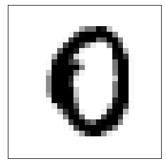

```python
# plot the values as pixels in a 28x28 square
plot_number(X[0])
```

[output not shown]

# Using this information, we can fit a number of different models using Python's sklearn package

`sklearn` makes it VERY easy to fit models and apply them to test data--using a simple `model.fit` and `model.predict` format.

### Let's see a K-Nearest Neighbors example...

[figure not shown]

# Recall our training data:

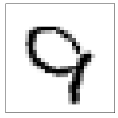

```python
print("This is a " + str(Y[5]))
plot_number(X[5])
```

## Initiate (create) a model object

```python
model = KNeighborsClassifier(n_neighbors=1)
```

## Fit the model with our training data and labels

```python
model.fit(mini_train_data, mini_train_labels)
```

## Use the model to predict labels for some test data

```python
predicted = model.predict(dev_data)
```

# What do we get?

```python
# Look at first 100 of our predicted labels
predicted[:100]
```

```
array(['8', '4', '1', '9', '6', '6', '3', '2', '1', '0', '8', '3', '1',
       '1', '3', '7', '1', '9', '4', '2', '2', '8', '9', '1', '7', '9',
       '9', '2', '1', '5', '3', '2', '8', '8', '1', '4', '1', '7', '4',
       '7', '4', '5', '6', '7', '7', '5', '7', '3', '1', '7', '6', '8',
       '1', '6', '2', '7', '1', '7', '9', '8', '7', '4', '0', '5', '0',
       '7', '1', '9', '8', '3', '5', '0', '6', '0', '6', '1', '8', '1',
       '9', '1', '0', '8', '6', '3', '1', '8', '3', '2', '1', '5', '6',
       '1', '9', '8', '4', '7', '4', '6', '8', '1'], dtype=object)
```

# Ok... are we done?

There are a lot of different variables to consider when you are fitting a model.

### What are some of the factors that might affect the accuracy of your model?

# Training Set Size ~ Model Accuracy Example

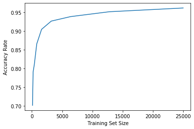

```python
# Make a plot of the accuracy rates for models built with different sized training sets
plot_accuracy_rates([100, 200, 400, 800, 1600, 3200, 6400, 12800, 25000])
```

# Spam Classification Demo

BIG thank you to [Mohit's Kaggle post](https://www.kaggle.com/mohitr/simple-spam-filter) for providing material for this demo

# What are some features of an email that might indicate it is spam?

# For our example, we are just going to look at the text content of the email

### Just like the last example, we need to start with training data for our model

```python
# Import a training set
dataset = pd.read_csv("emails.csv", usecols=[0,1])

# Get rid of duplicates or records with missing values
dataset.drop_duplicates(inplace=True)
dataset.dropna(inplace=True)

# Preview the data
dataset.head()
```

|  | text | spam |
| --- | --- | --- |
| 0 | Subject: naturally irresistible your corporate... | 1 |
| 1 | Subject: the stock trading gunslinger fanny i... | 1 |
| 2 | Subject: unbelievable new homes made easy im ... | 1 |
| 3 | Subject: 4 color printing special request add... | 1 |
| 4 | Subject: do not have money , get software cds ... | 1 |

# Bag of Words Model

[figure not shown]

Source: https://ldabook.com/Images/BagOfWords.png

## Let's Clean Up Our Training Data

## The next few steps will:

1. Break each sentence into a list of individual words ("tokens").
2. Remove words with little value.
3. Remove special characters that might confuse our model.
4. Apply *lemmatization* to bring modified words back to their root form.

```python
# 1: Tokenization
dataset['tokens'] = dataset['text'].map(lambda text:  nltk.tokenize.word_tokenize(text))
print(dataset['tokens'][1])
```

```
['Subject', ':', 'the', 'stock', 'trading', 'gunslinger', 'fanny', 'is', 'merrill', 'but', 'muzo', 'not', 'colza', 'attainder', 'and', 'penultimate', 'like', 'esmark', 'perspicuous', 'ramble', 'is', 'segovia', 'not', 'group', 'try', 'slung', 'kansas', 'tanzania', 'yes', 'chameleon', 'or', 'continuan…
```

```python
# 2: Remove stop words
stop_words = set(nltk.corpus.stopwords.words('english'))
dataset['filtered_text'] = dataset['tokens'].map(lambda tokens: [w for w in tokens if not (w in stop_words)])

# 2: Every record starts with "Subject :"--remove this
dataset['filtered_text'] = dataset['filtered_text'].map(lambda text: text[2:])
```

```python
# 3: Remove special characters
## First we bring all words back together in one string for efficiency reasons
dataset['filtered_text'] = dataset['filtered_text'].map(lambda text: ' '.join(text))
dataset['filtered_text'] = dataset['filtered_text'].map(lambda text: re.sub('[^A-Za-z0-9]+', ' ', text))
```

```python
# 4: Apply lemmatization (using a handy pre-made package!)
wnl = nltk.WordNetLemmatizer()
dataset['filtered_text'] = dataset['filtered_text'].map(lambda text: wnl.lemmatize(text))
```

# Now let's take a look at the transformed data

```python
dataset.head()
```

|  | text | spam | tokens | filtered_text |
| --- | --- | --- | --- | --- |
| 0 | Subject: naturally irresistible your corporate... | 1 | [Subject, :, naturally, irresistible, your, co... | naturally irresistible corporate identity lt r... |
| 1 | Subject: the stock trading gunslinger fanny i... | 1 | [Subject, :, the, stock, trading, gunslinger, ... | stock trading gunslinger fanny merrill muzo co... |
| 2 | Subject: unbelievable new homes made easy im ... | 1 | [Subject, :, unbelievable, new, homes, made, e... | unbelievable new homes made easy im wanting sh... |
| 3 | Subject: 4 color printing special request add... | 1 | [Subject, :, 4, color, printing, special, requ... | 4 color printing special request additional in... |
| 4 | Subject: do not have money , get software cds ... | 1 | [Subject, :, do, not, have, money, ,, get, sof... | money get software cds software compatibility ... |

## Now we can build our model!

```python
# CountVectorizer will count the frequency of the different words for each record
cv = CountVectorizer()
counts = cv.fit_transform(dataset['filtered_text'].values)
labels = dataset['spam'].values # Pull out just the 'spam' column for our labels
```

# Let's look at the shapes to get an idea of what this looks like

```python
print("Training Data: ", counts.shape)
print("Training Labels: ", labels.shape)
```

```
Training Data:  (5695, 37034)
Training Labels:  (5695,)
```

## Again, we are going to use the "fit, predict" workflow to create the model

## Fit a model

This time we are using a Naive Bayes model instead of K-Nearest Neighbors.

Naive Bayes uses statistics to evaluate the frequencies of each word and develop a likelihood of the email being spam.

```python
model = MultinomialNB()
model.fit(X_train, y_train)
```

```
MultinomialNB(alpha=1.0, class_prior=None, fit_prior=True)
```

## Now let's use this model to predict whether the following emails are spam

[output not shown]

```python
ham_email = '''Hi cF team,

Please have a look at this note below from Medallia's tech support team.

Apparently my name is listed as the contact in Medallia's SFDC for Verizon's role/access change requests.   I can certainly help out with the Verizon Business Group requests, but I do not know how to help in the case of the VCG Medallia Mobile piece.

Are you able to assist them?



Mary Lynn Scanlon'''

spam_email = '''
TERMINIX

90+ YEARS

EXPERIENCE
GUARANTEED PEST CONTROL

We'll do whatever it takes, by coming back between treatments at no cost, until pests are gone.1

100%
SATISFACTION

GUARANTEE

SAVE $502

ON A TERMINIX PEST CONTROL PLAN3

100% Satisfaction guarantee

America's leading provider in termite and pest control services

Annual coverage from top pest threats3


GET A FREE ESTIMATE »

1 If within 30 days after an inspection or treatment you aren't totally satisfied, we will refund the applicable treatment or coverage charges, reimburse any prepaid services and cancel your plan.

2 Offer valid only at participating locations. Single-family dwelling unid only. Requires purchase of a new annual residential pest control plan. Offer may not be combined with other offers, bundled service offerings or other discounts.. Additional limitations apply. Not valid for existing pest control customers.

3 Standard Covered Pests: cockroaches. mice. rats. silverfish, "house" ants (excluding carpenter ants, fire ants, pharaoh ants and tawny crazy ants), clothes moths, spiders (excluding black widow and brown recluse spiders), scorpions, centipedes, millipedes, earwigs house crickets and paper wasps. Other pests not specified as Standard Covered Pests may be covered for an additional charge or under other plans.


©2020 The Terminix International Company Limited Partnership. All rights reserved.

This is an Advertisement.
The Terminix International Company Limited Partnership, 150 Peabody Place, Memphis, TN 38103
We respect your privacy. View our policy.
Unsubscribe

'''
```

## Get frequency counts of the words from our original model

This is what we will feed into the NLP model.

```python
examples = [spam_email, ham_email]
counts = cv.transform(examples)
counts.shape
```

```
(2, 37034)
```

```python
model.predict(counts)
```

```
array(['1', '0'], dtype='<U92')
```